# IBM's Employee Attrition Exploration

# by Eniola Ogunmona

1. Introduction
2. Data Wrangling
3. Explortory Data Analysis
4. Research Question 1
5. Research Question 2
6. Research Question 3
7. Research Question 4
8. Research Question 5
9. Conclusion

## Introduction

This document explores a dataset containing information relating to employee attrition including attrition, monthly income, job satisfaction, performance rating, age, no. of years worked. Employee attrition is when an employee ceases working for a company for any reason and is not replaced for a long time.

> **Questions explored in this notebook**:
> - What are the factors behind employee attrition?
> - What is the relationship between Education and Monthly Income?
> - What is the effect of age on attrition?
> - Is Income the main factor towards employee attrition?
> - How does work-life balance impact the overall attrition rate?

## Data Wrangling

```python
# Importing useful libraries

import sqlite3
import pandas as pd
import numpy as np
import matplotlib.pyplot as plt
import seaborn as sns
sns.set_style("darkgrid")
sns.set_palette("mako")
default_color = sns.color_palette()[1]
%matplotlib inline
```

### Data Gathering

The data for this exploration will be gathered and loaded from an SQL database.

```python
# Gathering the data from the database
path ="attr_data.db"
conn = sqlite3.connect(path)
cur = conn.cursor()

attr_df = pd.read_sql_query ('''
                               SELECT *
                               FROM attrition_records
                               ''', conn)
```

```python
# let's see a sample of the dataset
attr_df.sample(10)
```

|  | id | Age | Attrition | BusinessTravel | DailyRate | Department | DistanceFromHome | Education | EducationField | EmployeeCount | ... | RelationshipSatisfaction | StandardHours | StockOptionLevel | TotalWorkingYears | TrainingTimesLastYear | WorkLifeBalance | YearsAtCompany | YearsInCurrentRole | YearsSinceLastPromotion | YearsWithCurrManager |
| --- | --- | --- | --- | --- | --- | --- | --- | --- | --- | --- | --- | --- | --- | --- | --- | --- | --- | --- | --- | --- | --- |
| 797 | 798 | 26 | Yes | Travel_Rarely | 1330 | Research & Development | 21 | 3 | Medical | 1 | ... | 3 | 80 | 1 | 1 | 0 | 2 | 1 | 1 | 0 | 0 |
| 1302 | 1303 | 35 | No | Travel_Rarely | 185 | Research & Development | 23 | 4 | Medical | 1 | ... | 2 | 80 | 1 | 6 | 2 | 4 | 5 | 4 | 0 | 3 |
| 219 | 220 | 54 | No | Travel_Rarely | 1147 | Sales | 3 | 3 | Marketing | 1 | ... | 4 | 80 | 1 | 16 | 4 | 3 | 6 | 2 | 0 | 5 |
| 200 | 201 | 27 | No | Travel_Frequently | 472 | Research & Development | 1 | 1 | Technical Degree | 1 | ... | 3 | 80 | 1 | 6 | 1 | 3 | 2 | 2 | 2 | 0 |
| 1415 | 1416 | 33 | No | Non-Travel | 1313 | Research & Development | 1 | 2 | Medical | 1 | ... | 3 | 80 | 3 | 1 | 2 | 2 | 1 | 1 | 0 | 0 |
| 557 | 558 | 35 | No | Non-Travel | 1225 | Research & Development | 2 | 4 | Life Sciences | 1 | ... | 1 | 80 | 1 | 16 | 2 | 4 | 1 | 0 | 0 | 0 |
| 327 | 328 | 39 | Yes | Travel_Rarely | 1162 | Sales | 3 | 2 | Medical | 1 | ... | 1 | 80 | 0 | 12 | 3 | 2 | 1 | 0 | 0 | 0 |
| 1442 | 1443 | 29 | Yes | Travel_Rarely | 1092 | Research & Development | 1 | 4 | Medical | 1 | ... | 2 | 80 | 3 | 4 | 3 | 4 | 2 | 2 | 2 | 2 |
| 1107 | 1108 | 38 | No | Travel_Frequently | 888 | Human Resources | 10 | 4 | Human Resources | 1 | ... | 3 | 80 | 0 | 10 | 2 | 3 | 6 | 3 | 1 | 2 |
| 1123 | 1124 | 35 | No | Travel_Rarely | 670 | Research & Development | 10 | 4 | Medical | 1 | ... | 3 | 80 | 0 | 10 | 4 | 3 | 5 | 2 | 0 | 4 |

10 rows × 36 columns

### Assessing Data

```python
# What's the shape of the dataset
attr_df.shape
```

```
(1470, 36)
```

```python
# let's see some more details
attr_df.info()
```

```
<class 'pandas.core.frame.DataFrame'>
RangeIndex: 1470 entries, 0 to 1469
Data columns (total 36 columns):
 #   Column                    Non-Null Count  Dtype
---  ------                    --------------  -----
 0   id                        1470 non-null   int64
 1   Age                       1470 non-null   int64
 2   Attrition                 1470 non-null   object
 3   BusinessTravel            1470 non-null   object
 4   DailyRate                 1470 non-null   int64
 5   Department                1470 non-null   object
 6   DistanceFromHome          1470 non-null   int64
 7   Education                 1470 non-null   int64
 8   EducationField            1470 non-null   object
 9   EmployeeCount             1470 non-null   int64
```

[output cut: 28 more lines]

```python
# let's take a look at som statistics
attr_df.describe()
```

|  | id | Age | DailyRate | DistanceFromHome | Education | EmployeeCount | EmployeeNumber | EnvironmentSatisfaction | HourlyRate | JobInvolvement | ... | RelationshipSatisfaction | StandardHours | StockOptionLevel | TotalWorkingYears | TrainingTimesLastYear | WorkLifeBalance | YearsAtCompany | YearsInCurrentRole | YearsSinceLastPromotion | YearsWithCurrManager |
| --- | --- | --- | --- | --- | --- | --- | --- | --- | --- | --- | --- | --- | --- | --- | --- | --- | --- | --- | --- | --- | --- |
| count | 1470.000000 | 1470.000000 | 1470.000000 | 1470.000000 | 1470.000000 | 1470.0 | 1470.000000 | 1470.000000 | 1470.000000 | 1470.000000 | ... | 1470.000000 | 1470.0 | 1470.000000 | 1470.000000 | 1470.000000 | 1470.000000 | 1470.000000 | 1470.000000 | 1470.000000 | 1470.000000 |
| mean | 735.500000 | 36.923810 | 802.485714 | 9.192517 | 2.912925 | 1.0 | 1024.865306 | 2.721769 | 65.891156 | 2.729932 | ... | 2.712245 | 80.0 | 0.793878 | 11.279592 | 2.799320 | 2.761224 | 7.008163 | 4.229252 | 2.187755 | 4.123129 |
| std | 424.496761 | 9.135373 | 403.509100 | 8.106864 | 1.024165 | 0.0 | 602.024335 | 1.093082 | 20.329428 | 0.711561 | ... | 1.081209 | 0.0 | 0.852077 | 7.780782 | 1.289271 | 0.706476 | 6.126525 | 3.623137 | 3.222430 | 3.568136 |
| min | 1.000000 | 18.000000 | 102.000000 | 1.000000 | 1.000000 | 1.0 | 1.000000 | 1.000000 | 30.000000 | 1.000000 | ... | 1.000000 | 80.0 | 0.000000 | 0.000000 | 0.000000 | 1.000000 | 0.000000 | 0.000000 | 0.000000 | 0.000000 |
| 25% | 368.250000 | 30.000000 | 465.000000 | 2.000000 | 2.000000 | 1.0 | 491.250000 | 2.000000 | 48.000000 | 2.000000 | ... | 2.000000 | 80.0 | 0.000000 | 6.000000 | 2.000000 | 2.000000 | 3.000000 | 2.000000 | 0.000000 | 2.000000 |
| 50% | 735.500000 | 36.000000 | 802.000000 | 7.000000 | 3.000000 | 1.0 | 1020.500000 | 3.000000 | 66.000000 | 3.000000 | ... | 3.000000 | 80.0 | 1.000000 | 10.000000 | 3.000000 | 3.000000 | 5.000000 | 3.000000 | 1.000000 | 3.000000 |
| 75% | 1102.750000 | 43.000000 | 1157.000000 | 14.000000 | 4.000000 | 1.0 | 1555.750000 | 4.000000 | 83.750000 | 3.000000 | ... | 4.000000 | 80.0 | 1.000000 | 15.000000 | 3.000000 | 3.000000 | 9.000000 | 7.000000 | 3.000000 | 7.000000 |
| max | 1470.000000 | 60.000000 | 1499.000000 | 29.000000 | 5.000000 | 1.0 | 2068.000000 | 4.000000 | 100.000000 | 4.000000 | ... | 4.000000 | 80.0 | 3.000000 | 40.000000 | 6.000000 | 4.000000 | 40.000000 | 18.000000 | 15.000000 | 17.000000 |

8 rows × 27 columns

```python
# Are there missing values
attr_df.isna().sum()
```

```
id                          0
Age                         0
Attrition                   0
BusinessTravel              0
DailyRate                   0
Department                  0
DistanceFromHome            0
Education                   0
EducationField              0
EmployeeCount               0
EmployeeNumber              0
EnvironmentSatisfaction     0
Gender                      0
HourlyRate                  0
JobInvolvement              0
JobLevel                    0
JobRole                     0
JobSatisfaction             0
MaritalStatus               0
MonthlyIncome               0
MonthlyRate                 0
NumCompaniesWorked          0
Over18                      0
OverTime                    0
PercentSalaryHike           0
PerformanceRating           0
RelationshipSatisfaction    0
StandardHours               0
StockOptionLevel            0
TotalWorkingYears           0
TrainingTimesLastYear       0
WorkLifeBalance             0
YearsAtCompany              0
YearsInCurrentRole          0
YearsSinceLastPromotion     0
YearsWithCurrManager        0
dtype: int64
```

```python
# Checking for duplicates
attr_df.id.duplicated().sum()
```

```
0
```

### Structure of the dataset

> This data set contains 1470 rows and 36 variables relating to employee attrition including attrition, monthly income, job satisfaction, performance rating, age, no. of years worked.

> Most variables are categorical in nature especially ordered factor variables showing levels and ratings.

### Main feature of interest in the dataset?

> I am most interested in the factors that affect employee attrition

### Features in the dataset I think will help support the investigation into the feature of interest?

> The monthly income and age should have an important effect on employee attrition. I expect the no. of years worked, job satisfaction and work life balance to also have an effect

## Exploratory Data Analysis

Let's explore the different variables in the dataset

```python
# What is the attrition rate
attr_df.Attrition.value_counts()
```

```
No     1233
Yes     237
Name: Attrition, dtype: int64
```

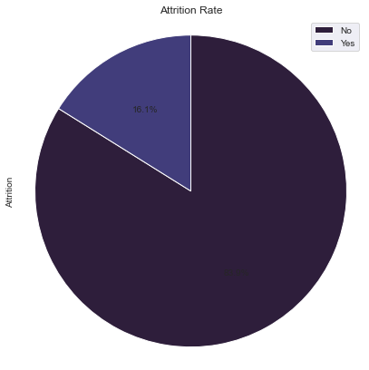

```python
# Let's see the percentage in a pie chart
sorted_counts = attr_df["Attrition"].value_counts()
plt.figure(figsize=(7,7))
plt.pie(sorted_counts, startangle = 90, counterclock = False, autopct='%1.1f%%')
plt.axis("square")
plt.title("Attrition Rate")
plt.ylabel("Attrition")
plt.legend(["No", "Yes"]);
```

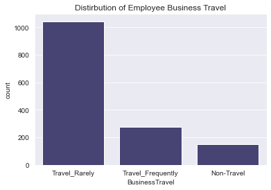

```python
# Let's see the distirbution of employee business travel
order = attr_df.BusinessTravel.value_counts().index
sns.countplot(data=attr_df, x="BusinessTravel", color=default_color, order=order)
plt.title("Distirbution of Employee Business Travel");
```

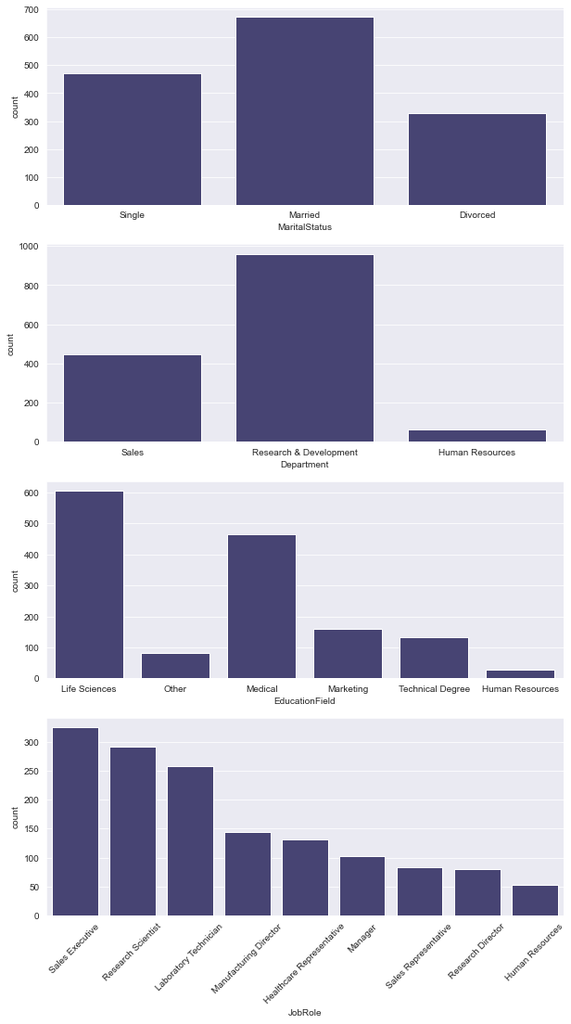

```python
# Let's see the distribution of a number of categorical variables
fig, ax = plt.subplots(nrows=4, figsize = [10,18])

sns.countplot(data=attr_df, x="MaritalStatus", color = default_color, ax = ax[0])
sns.countplot(data=attr_df, x="Department", color = default_color, ax = ax[1])
sns.countplot(data=attr_df, x="EducationField", color = default_color, ax = ax[2])
sns.countplot(data=attr_df, x="JobRole", color = default_color, ax = ax[3])
plt.xticks(rotation=45)
plt.show()
```

**There are a number of ordinal variables, let's convert them into an ordered categorical type**

```python
# Converting columns from a plain object type into an ordered categorical type
# List of columns
ordinal_var_dict = {
                    "WorkLifeBalance": [1, 2, 3, 4],
                    "JobSatisfaction": [1, 2, 3, 4],
                    "RelationshipSatisfaction": [1, 2, 3, 4],
                    "Education": [1, 2, 3, 4, 5],
                    "EnvironmentSatisfaction": [1, 2, 3, 4],
                    "PerformanceRating": [3, 4],
                    "JobInvolvement": [1, 2, 3, 4],
                    "JobLevel": [1, 2, 3, 4, 5],
                    "StockOptionLevel": [0, 1, 2, 3]
                   }
# Returns the types with the categories & orderedness and uses pandas.astype() to convert
# from a plain object type into an ordered categorical type
for var in ordinal_var_dict:
    ordered_var = pd.api.types.CategoricalDtype(ordered = True, categories = ordinal_var_dict[var])
    attr_df[var] = attr_df[var].astype(ordered_var)
```

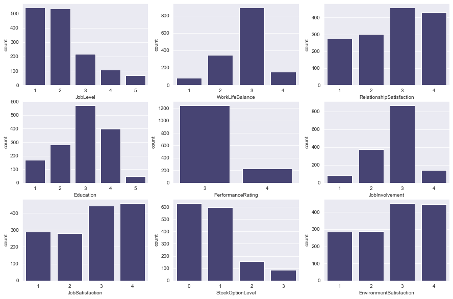

```python
# Let's see the distribution of a number of categorical variables
fig, ax = plt.subplots(nrows=3, ncols=3, figsize = [15,10])

sns.countplot(data=attr_df, x="JobLevel", color = default_color, ax = ax[0,0])
sns.countplot(data=attr_df, x="WorkLifeBalance", color = default_color, ax = ax[0,1])
sns.countplot(data=attr_df, x="RelationshipSatisfaction", color = default_color, ax = ax[0,2])
sns.countplot(data=attr_df, x="Education", color = default_color, ax = ax[1,0])
sns.countplot(data=attr_df, x="PerformanceRating", color = default_color, ax = ax[1,1])
sns.countplot(data=attr_df, x="JobInvolvement", color = default_color, ax = ax[1,2])
sns.countplot(data=attr_df, x="JobSatisfaction", color = default_color, ax = ax[2,0])
sns.countplot(data=attr_df, x="StockOptionLevel", color = default_color, ax = ax[2,1])
sns.countplot(data=attr_df, x="EnvironmentSatisfaction", color = default_color, ax = ax[2,2])
plt.show()
```

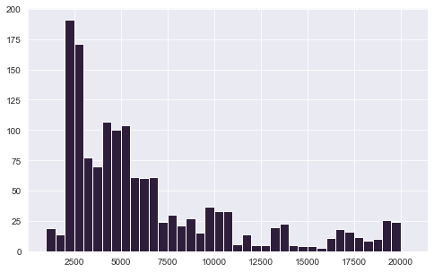

```python
plt.figure(figsize=[8, 5])
bins = np.arange(1000, attr_df["MonthlyIncome"].max()+1000, 500)
plt.hist(data=attr_df, x="MonthlyIncome", bins=bins);
```

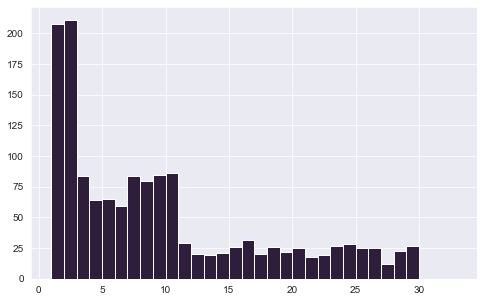

```python
plt.figure(figsize=[8, 5])
bins = np.arange(1, attr_df["DistanceFromHome"].max()+5, 1)
plt.hist(data=attr_df, x="DistanceFromHome", bins=bins);
```

**Let's go on ahead to look at the relationship between the variables in the dataset and ask questions**

## 1. What are the factors behind employee attrition?

Let's explore a couple of relationships to understand this question

### What effect does monthly income have on employee attrition?

```python
attr_df.groupby("Attrition")["MonthlyIncome"].describe()
```

| Attrition | count | mean | std | min | 25% | 50% | 75% | max |
| --- | --- | --- | --- | --- | --- | --- | --- | --- |
| No | 1233.0 | 6832.739659 | 4818.208001 | 1051.0 | 3211.0 | 5204.0 | 8834.0 | 19999.0 |
| Yes | 237.0 | 4787.092827 | 3640.210367 | 1009.0 | 2373.0 | 3202.0 | 5916.0 | 19859.0 |

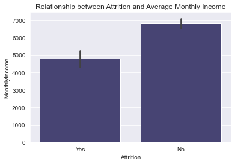

```python
# Let's look at the relationship between atrrition and monthly income
sns.barplot(data=attr_df, x="Attrition", y="MonthlyIncome", color=default_color)
plt.title("Relationship between Attrition and Average Monthly Income");
```

We can see that on the average employees with lower salary ranges are no longer working. This seems like an important factor affecting employee attrition

### What is the relationship between age and employee attrition?

```python
attr_df.groupby("Attrition")["Age"].describe()
```

| Attrition | count | mean | std | min | 25% | 50% | 75% | max |
| --- | --- | --- | --- | --- | --- | --- | --- | --- |
| No | 1233.0 | 37.561233 | 8.88836 | 18.0 | 31.0 | 36.0 | 43.0 | 60.0 |
| Yes | 237.0 | 33.607595 | 9.68935 | 18.0 | 28.0 | 32.0 | 39.0 | 58.0 |

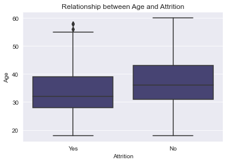

```python
# Let's look at the relationship between age and attrition
sns.boxplot(data=attr_df, x="Attrition", y="Age", color=default_color)
plt.title("Relationship between Age and Attrition");
```

The box plot shows that there's employee attrition within those of younger ages. It could mean that young employees have more freedom to move from one company to another.

### How does the no. of years spent at company relate to employee attrition?

```python
attr_df.groupby("Attrition")["YearsAtCompany"].describe()
```

| Attrition | count | mean | std | min | 25% | 50% | 75% | max |
| --- | --- | --- | --- | --- | --- | --- | --- | --- |
| No | 1233.0 | 7.369019 | 6.096298 | 0.0 | 3.0 | 6.0 | 10.0 | 37.0 |
| Yes | 237.0 | 5.130802 | 5.949984 | 0.0 | 1.0 | 3.0 | 7.0 | 40.0 |

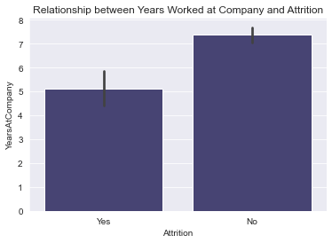

```python
# Let's look at the relationship between years worked at company and attrition
sns.barplot(data=attr_df, x="Attrition", y="YearsAtCompany", color=default_color)
plt.title("Relationship between Years Worked at Company and Attrition");
```

On the average, those who spend lesser years (5 years and below) at a company are more likely to leave. It can be said that spending a lot of years (over 7 years) at a company makes employees less likely to leave.

### Does the distance from home have an effect on employee attrition?

```python
attr_df.groupby("Attrition")["DistanceFromHome"].describe()
```

| Attrition | count | mean | std | min | 25% | 50% | 75% | max |
| --- | --- | --- | --- | --- | --- | --- | --- | --- |
| No | 1233.0 | 8.915653 | 8.012633 | 1.0 | 2.0 | 7.0 | 13.0 | 29.0 |
| Yes | 237.0 | 10.632911 | 8.452525 | 1.0 | 3.0 | 9.0 | 17.0 | 29.0 |

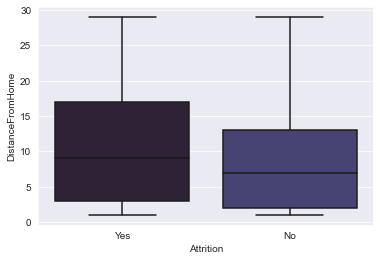

```python
sns.boxplot(data=attr_df, x="Attrition", y="DistanceFromHome");
```

From the box plot, employees from a farther distance (average of 10 km) from home tend to leve their jobs than those who stay closer.

### What is the relationship between total no. of years worked and monthly income?

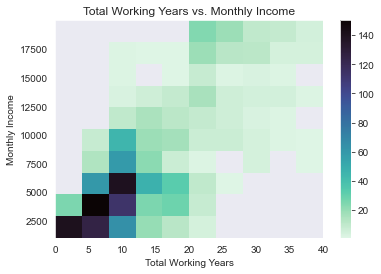

```python
# Using a heat map to see the relationship between total no. of years worked and monthly income
plt.hist2d(data=attr_df, x="TotalWorkingYears", y="MonthlyIncome", cmin=0.55, cmap="mako_r")
plt.colorbar()
plt.title("Total Working Years vs. Monthly Income")
plt.xlabel("Total Working Years")
plt.ylabel("Monthly Income");
```

There's a positive relationship between total no. of years worked and monthly income. Most employees are just starting out with a few years of experience and a low range monthly income betwee 2500-10000

### Is there any relationship between attrition and the ordinal variables?

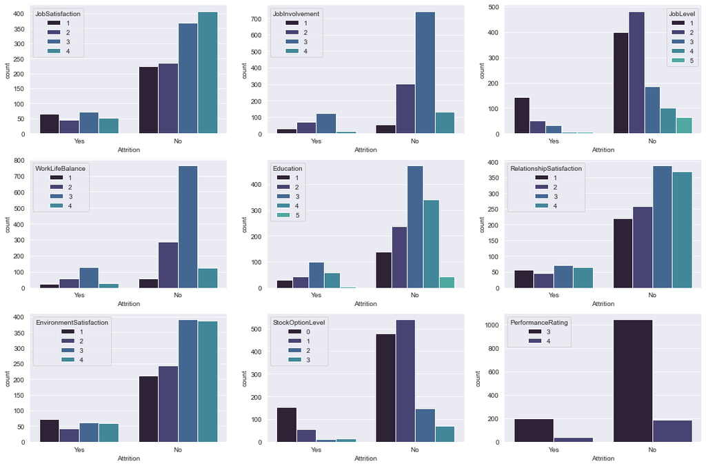

```python
fig, ax = plt.subplots(nrows=3, ncols=3, figsize = [18,12])

sns.countplot(data=attr_df, x="Attrition", hue="JobSatisfaction", ax = ax[0,0])
sns.countplot(data=attr_df, x="Attrition", hue="JobInvolvement", ax = ax[0,1])
sns.countplot(data=attr_df, x="Attrition", hue="JobLevel", ax = ax[0,2])
sns.countplot(data=attr_df, x="Attrition", hue="WorkLifeBalance", ax = ax[1,0])
sns.countplot(data=attr_df, x="Attrition", hue="Education", ax = ax[1,1])
sns.countplot(data=attr_df, x="Attrition", hue="RelationshipSatisfaction", ax = ax[1,2])
sns.countplot(data=attr_df, x="Attrition", hue="EnvironmentSatisfaction", ax = ax[2,0])
sns.countplot(data=attr_df, x="Attrition", hue="StockOptionLevel", ax = ax[2,1])
sns.countplot(data=attr_df, x="Attrition", hue="PerformanceRating", ax = ax[2,2]);
```

From the plot generated,

- Looking at the relationship between Attrition and Job Satisfaction, those who report lower rates of job satisfaction leave the company
- Looking at the relationship between Attrition and Job Involvement, those who are deeply involved in work (with rating above 2) remain at the company
- Looking at the relationship between Attrition and Job Level, those in the lower rank (level 1) tend to leave while those from level 2 remain. This could mean just being promoted to the next level encourages employees to stay
- Looking at the relationship between Attrition and Work Life Balance, the groups of bars generated for both employees that leave or stay are distributed in the same way. There do not seem to be any relationship between attrition and work life balance
- Looking at the relationship between Attrition and Education, the largest bar can be seen from those who stay at the company and have level 3 education followed by level 4. We may say the higher the level of education the lower the attrition.
- Looking at the relationship between Attrition and Relationship Satisfaction, the bars in both employees that leave or stay are almost identical. There do not seem to be any relationship between attrition and relationship satisfaction
- Looking at the relationship between Attrition and Environment Satisfaction, the bars in both groups seem identical but looking closer at the bars for those that leave employees experiencing the lowest level of satisfaction occurs the highest. We may say Environment Satisfaction has a slight imapct on employee attrition
- Looking at the relationship between Attrition and Stock Option Level, amongst the employee that choose to stay there are more employees enjoying higher stock level option while amongst those that leave more enjoy lower stock option levels.
- Looking at the relationship between Attrition and Performance Rating, the bars appear identical and there seems to be no relationship between attriton and performance rating

> From the exploration above looking at the factors behind employee attrition, I think these are the three main factors:
> - Monthly Income
> - Years worked at the company
> - Job Level

## 2. What is the relationship between education and monthly income?

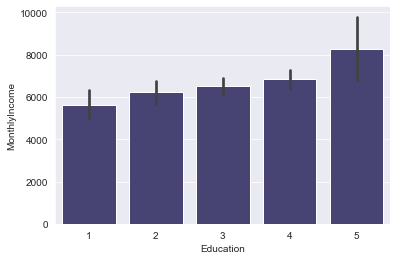

```python
# Let's look at the relationship between education and monthly income
sns.barplot(data=attr_df, x="Education", y="MonthlyIncome", color=default_color);
```

> Looking at the relationship between education and monthly income, the average monthly income rises as the education level increases (there is a positive relationship between the two variables).

## 3. What is the effect of age on attrition?

```python
attr_df.groupby("Attrition")["Age"].describe()
```

| Attrition | count | mean | std | min | 25% | 50% | 75% | max |
| --- | --- | --- | --- | --- | --- | --- | --- | --- |
| No | 1233.0 | 37.561233 | 8.88836 | 18.0 | 31.0 | 36.0 | 43.0 | 60.0 |
| Yes | 237.0 | 33.607595 | 9.68935 | 18.0 | 28.0 | 32.0 | 39.0 | 58.0 |

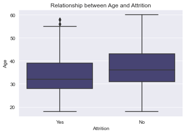

```python
# Let's look at the relationship between age and attrition again
sns.boxplot(data=attr_df, x="Attrition", y="Age", color=default_color)
plt.title("Relationship between Age and Attrition");
```

The box plot shows that there's employee attrition within those of younger ages. It could mean that young employees have more freedom to move from one company to another.

## 4. Is income the main factor towards employee attrition?

```python
attr_df.groupby("Attrition")["MonthlyIncome"].describe()
```

| Attrition | count | mean | std | min | 25% | 50% | 75% | max |
| --- | --- | --- | --- | --- | --- | --- | --- | --- |
| No | 1233.0 | 6832.739659 | 4818.208001 | 1051.0 | 3211.0 | 5204.0 | 8834.0 | 19999.0 |
| Yes | 237.0 | 4787.092827 | 3640.210367 | 1009.0 | 2373.0 | 3202.0 | 5916.0 | 19859.0 |

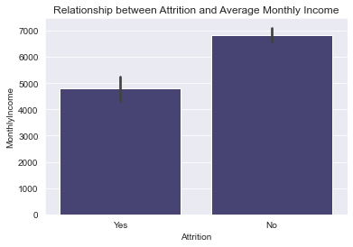

```python
# Let's look at the relationship between atrrition and monthly income again
sns.barplot(data=attr_df, x="Attrition", y="MonthlyIncome", color=default_color)
plt.title("Relationship between Attrition and Average Monthly Income");
```

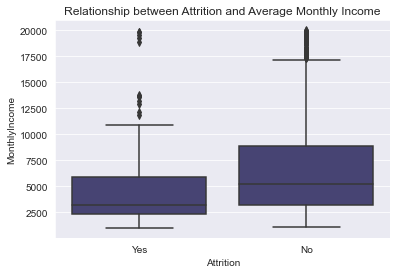

```python
# Let's look at the relationship between atrrition and monthly income on a box plot too
sns.boxplot(data=attr_df, x="Attrition", y="MonthlyIncome", color=default_color)
plt.title("Relationship between Attrition and Average Monthly Income");
```

On the average, employees with lower salary (4800) tend to stop working at the company. This seems like an important factor affecting employee attrition and I believe it is the main factor

## 5. How does work-life balance impact the overall attrition rate?

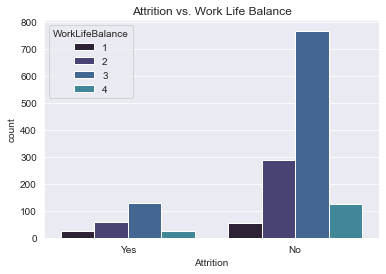

```python
# Let's take a look at the relationship between attrition and work-life balance
sns.countplot(data=attr_df, x="Attrition", hue="WorkLifeBalance")
plt.title("Attrition vs. Work Life Balance");
```

Looking at the relationship between Attrition and Work Life Balance, the groups of bars generated for both employees that leave or stay are distributed in the same way. There do not seem to be any relationship between attrition and work life balance so we can say work life balance has little or no impact on the overall attrition rate

## Conclusion

We looked IBM's employees attrition dataset then explored the following questions:

- What are the factors behind employee attrition?
- What is the relationship between Education and Monthly Income?
- What is the effect of age on attrition?
- Is Income the main factor towards employee attrition?
- How does work-life balance impact the overall attrition rate?

Here are the findings from the exploration carried out:

1. **What are the factors behind employee attrition?**

   I think these are the three main factors:
- Monthly Income: On the average employees with lower salary (an average of 4800) are no longer working. This seems like an important factor affecting employee attrition
- Years worked at the company: It is seen on the average that employees who spend lesser years (5 years and below) at the company are more likely to leave. It can be said that spending a few years at the company can easily move but those who spend a lot of years (7 years and above) at the company makes the employees less likely to leave.
- Job Level: We can see those in the lower rank (level 1) tend to leave while those from level 2 remain. This could mean just being promoted to the next level encourages employees to stay.
1. **What is the relationship between Education and Monthly Income?**
- Looking at the relationship between education and monthly income, the average monthly income rises as the education level increases. There is a positive relationship between the two variables.
1. **What is the effect of age on attrition?**
- There seem to be employee attrition within those of younger ages (average off 33 years and younger). It could mean that young employees have more freedom to move from one company to another.
1. **Is Income the main factor towards employee attrition?**
- On the average, employees with lower salary ranges tend to stop working at the company. There seems to be a strong relationship and it can be considered an important factor affecting employee attrition. I believe it is the main factor
1. **How does work-life balance impact the overall attrition rate?**
- There do not seem to be any relationship between attrition and work life balance so we can say work life balance has little or no impact on the overall attrition rate